# R Notebook

```r
---
title: "BLM data analysis"
output: html_notebook
---
```

*Installing required packages*

```r
library(rtweet)
library(tidyr)
library(ggplot.multistats)
library(ggplot2)
library(forestmangr)
library(syuzhet)
library(tidyverse)
library(readxl) # read excel
library(tibble) # tobble dataframe
library(dplyr) # piping
library(stringr) # character manipulation
library(tidytext)
library(tokenizers)
library(stopwords)
library(lobstr)
library(glue)
```

*Loading the data*

```r
blm_merged<-read.csv('../../gen/data-preparation/merging.csv', sep = ',', na.strings=c("", "NA"))
```

- set everything right *

```r
# remove first column
blm_merged <- subset(blm_merged, select = -row.names)

# set user_created_date as date
blm_merged$user_created_date <- as.Date(blm_merged$user_created_date, format = c("%Y-%m-%d"))

# Set date into as.Date
blm_merged$date <- as.Date(blm_merged$date)

# set variables with counting numbers into integers
blm_merged$reply <- as.integer(blm_merged$reply)
```

*Making dataframe with amount of retweets, likes and replies*

```r
#Retweet

RLR <- function(year){
    for (i in year){
      retweet <- (sum(blm_merged[blm_merged$year == year,]$retweet, na.rm = T))
      like <- (sum(blm_merged[blm_merged$year == year,]$like, na.rm = T))
      reply <- (sum(blm_merged[blm_merged$year == year,]$reply, na.rm = T))
    }
  RLRdata <- data.frame(category=c("Retweet", "Like", "Reply"), count = c(retweet, like, reply))
  return(RLRdata)
}

RLRdata2020 <- RLR(2020)
RLRdata2020
```

| category | count |
| --- | --- |
| Retweet | 11 |
| Like | 104 |
| Reply | 17 |

```r
RLRdata2021 <- RLR(2021)
```

*Visualizing the data 2020*

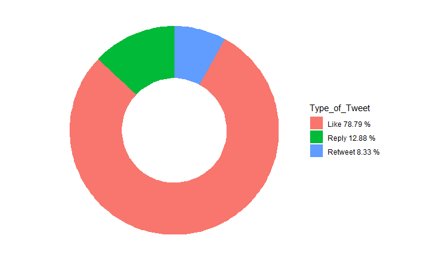

```r
#Adding columns

RLRdata2020$fraction = RLRdata2020$count / sum(RLRdata2020$count)
RLRdata2020$percentage = RLRdata2020$count / sum(RLRdata2020$count) * 100
RLRdata2020$ymax = cumsum(RLRdata2020$fraction)
RLRdata2020$ymin = c(0, head(RLRdata2020$ymax, n=-1))

#Rounding up

RLRdata2020 <- round_df(RLRdata2020, 2)

# Specify what the legend should say
Type_of_Tweet <- paste(RLRdata2020$category, RLRdata2020$percentage, "%")

ggplot(RLRdata2020, aes(ymax=ymax, ymin=ymin, xmax=4, xmin=3, fill=Type_of_Tweet)) +
  geom_rect() +
  coord_polar(theta="y") +
  xlim(c(2, 4)) +
  theme_void() +
  theme(legend.position = "right")
```

```r
NA
NA
NA
```

*Visualizing the data 2021*

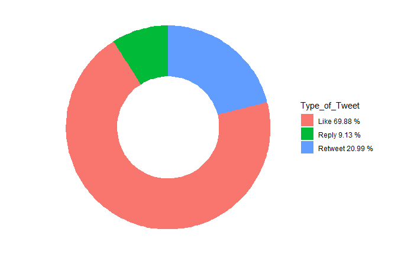

```r
#Adding columns

RLRdata2021$fraction = RLRdata2021$count / sum(RLRdata2021$count)
RLRdata2021$percentage = RLRdata2021$count / sum(RLRdata2021$count) * 100
RLRdata2021$ymax = cumsum(RLRdata2021$fraction)
RLRdata2021$ymin = c(0, head(RLRdata2021$ymax, n=-1))

#Rounding up

RLRdata2021 <- round_df(RLRdata2021, 2)

# Specify what the legend should say
Type_of_Tweet <- paste(RLRdata2021$category, RLRdata2021$percentage, "%")

ggplot(RLRdata2021, aes(ymax=ymax, ymin=ymin, xmax=4, xmin=3, fill=Type_of_Tweet)) +
  geom_rect() +
  coord_polar(theta="y") +
  xlim(c(2, 4)) +
  theme_void() +
  theme(legend.position = "right")
```

*Most frequent words in the tweets*

First, we want to remove stop words like “so” and “at” for counting the most frequent words

```r
tweets <- function(year){
  tweets <- blm_merged[blm_merged$year == year,] %>%
    select(text) %>%
    unnest_tokens(word, text)
  tweets <- tweets %>%
    anti_join(get_stopwords(language = "nl", source = "snowball"))
}
tweets(2020)
tweets(2021)
```

```r
#making a histogram

histogram_tweets <- function(year) {
  tweets(year) %>% # gives you a bar chart of the most frequent words found in the tweets
    count(word, sort = TRUE) %>%
    top_n(15) %>%
    mutate(word = reorder(word, n)) %>%
    ggplot(aes(x = word, y = n)) +
    geom_col() +
    xlab(NULL) +
    coord_flip() +
    labs(
      y = "Count",
      x = "Unique words",
      title = "Most frequent words found in the tweets of #BLM",
      subtitle = "Stop words removed from the list"
    )
}

histogram_tweets(2020)
```

```
Error in count(., word, sort = TRUE) : unused argument (sort = TRUE)
```

*Sentiment analysis for positive or negative tweets 2020*

To see the nature of the tweets we can make a sentiment analysis. We do that for both years again and see that in 2020 the negativity and positivity scores the highest. In 2021 we however see that the difference in sentiment scores is a bit bigger now: it’s more negative. That’s a noticable difference!

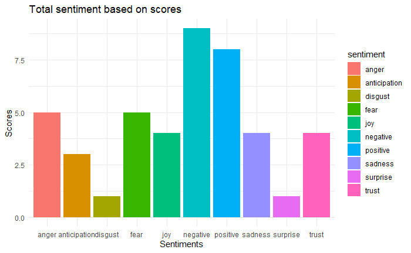

```r
sentiment <- function(year){
  tweets_sentiment <- iconv(tweets(year), from="UTF-8", to="ASCII", sub="")# Converting tweets to ASCII to        trackle strange characters

  # removing retweets, in case needed
  tweets_sentiment <-gsub("(RT|via)((?:\\b\\w*@\\w+)+)","",tweets_sentiment)

  # removing mentions, in case needed
  tweets_sentiment <-gsub("@\\w+","",tweets_sentiment)
  ew_sentiment<-get_nrc_sentiment((tweets_sentiment))
  sentimentscores<-data.frame(colSums(ew_sentiment[,]))
  names(sentimentscores) <- "Score"
  sentimentscores <- cbind("sentiment"=rownames(sentimentscores),sentimentscores)
  rownames(sentimentscores) <- NULL

  # make plot
  ggplot(data=sentimentscores,aes(x=sentiment,y=Score))+
    geom_bar(aes(fill=sentiment),stat = "identity")+
    theme(legend.position="none")+
    xlab("Sentiments")+ylab("Scores")+
    ggtitle("Total sentiment based on scores" )+
    theme_minimal()

}
sentiment(2020)
```

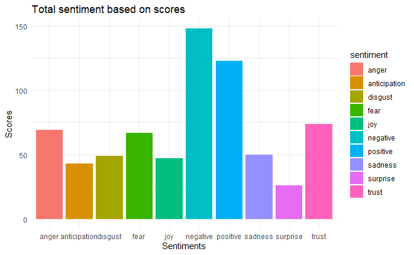

```r
sentiment(2021)
```

*Visualizing the variables in the dataset 2020*

We now want to visualize retweets by location.

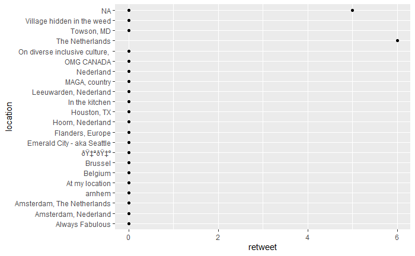

```r
retweet_location <- function(year){
  ggplot(data = blm_merged[blm_merged$year == year,]) +
    geom_point(mapping = aes(x = retweet, y = location))
}
retweet_location(2020)
```

[figure not shown]

```r
retweet_location(2021)
```

We now want to visualize the retweet by date for both years.

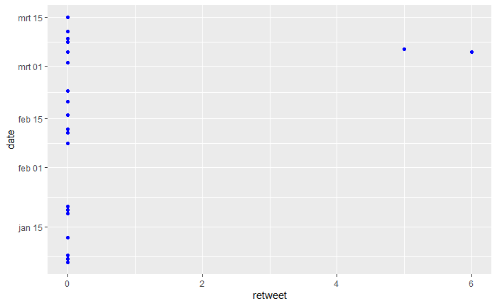

```r
retweet_date <- function(year){
  ggplot(data = blm_merged[blm_merged$year == year,]) +
    geom_point(mapping = aes(x = retweet, y = date), color = "blue")
}

retweet_date(2020)
```

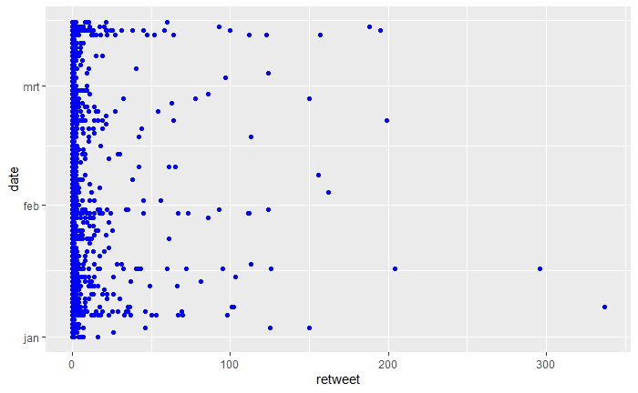

```r
retweet_date(2021)
```

*Graphing users amount of followers and user amount friends* We also want to visualize the relationship between the amount of followers and the amount of friens.

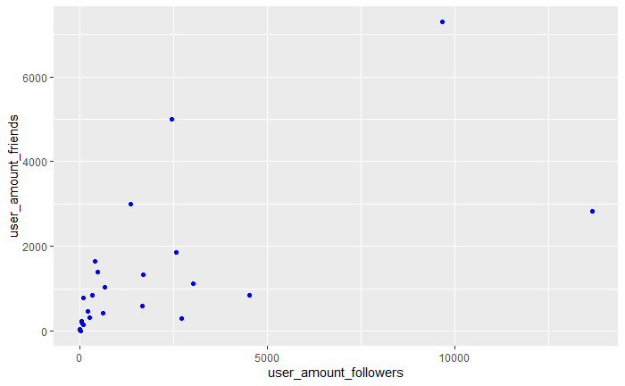

```r
followers_friends <- function(year){
  ggplot(data = blm_merged[blm_merged$year == year,]) +
    geom_point(mapping = aes(x = user_amount_followers, y = user_amount_friends), color = "blue")
}

followers_friends(2020)
```

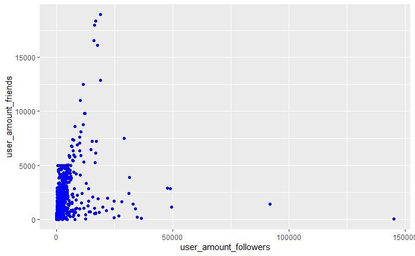

```r
followers_friends(2021)
```

*Graphing users amount status by location*

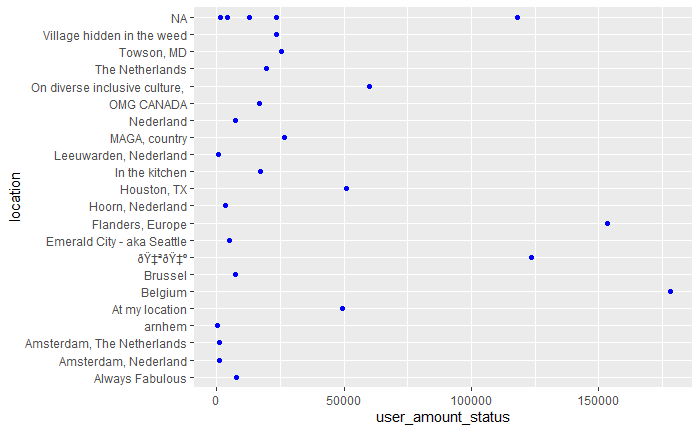

```r
status_location <- function(year){
  ggplot(data = blm_merged[blm_merged$year == year,]) +
    geom_point(mapping = aes(x = user_amount_status, y = location), color = "blue")
}

status_location(2020)
```

[figure not shown]

```r
status_location(2021)
```

#Filter if parties are mentioned in 2020

```r
state.name[grep ("VVD", "PvdA", "PVV", "CDA", "SP", "CU", "PvdD", state.name)]
```

```
character(0)
```

[output not shown]